# CITS4009 Project - Exploratory Data Analysis and Predictive Modeling

## **2.7. Using LIME for Model Interpretation**

We apply the Local Interpretable Model-agnostic Explanations (LIME) technique to interpret the predictions made by our Decision Tree classifier. LIME helps us understand the contribution of each feature to a particular prediction, offering insights into the model’s decision-making process for individual instances.

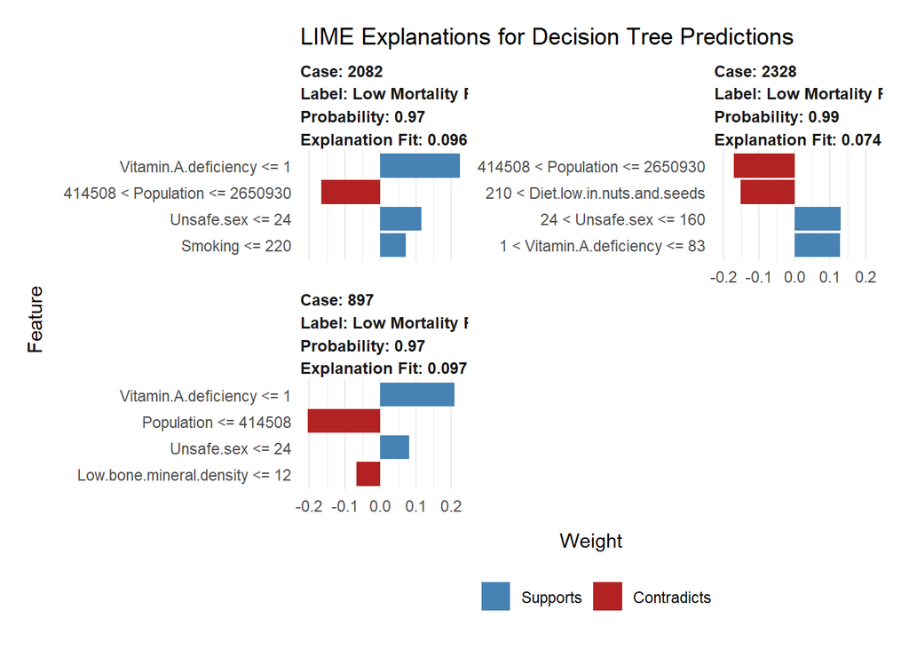

```r
# Define 'model_type' and 'predict_model' methods for 'rpart' models
model_type.rpart <- function(x, ...) {
  if (x$method == "class") "classification" else "regression"
}

predict_model.rpart <- function(x, newdata, type, ...) {
  if (type == "raw") {
    preds <- predict(x, newdata, type = "class")
    data.frame(Response = preds)
  } else if (type == "prob") {
    preds <- predict(x, newdata, type = "prob")
    as.data.frame(preds)
  } else {
    stop("Invalid prediction type")
  }
}

# Create the explainer using the training data
explainer <- lime(
  x = train_data[, -which(names(train_data) == "Mortality_Class")],
  model = tree_model,
  bin_continuous = TRUE
)

# Select a few instances from the test set for explanation
set.seed(123)
instances_to_explain <- test_data[sample(1:nrow(test_data), 3), ]

# Generate explanations using LIME
explanation <- explain(
  x = instances_to_explain[, -which(names(instances_to_explain) == "Mortality_Class")],
  explainer = explainer,
  n_features = 4,
  n_labels = 1
)

# Visualize the explanations
plot_features(explanation) +
  labs(title = "LIME Explanations for Decision Tree Predictions")
```

**Interpretation of Results:**

For each instance, LIME provided the predicted label, prediction probability, explanation fit, and the key features influencing the prediction. Below is a summary of the findings for the three instances:

**Instance 1 (Case 2082)**

The model predicted a **Low Mortality Rate** with a probability of **97%**. The features that most strongly supported this prediction were low levels of **Vitamin A deficiency**, **unsafe sex**, and **smoking**. These factors are associated with better health outcomes and lower mortality risks. However, the population size, which fell between 414,508 and 2,650,930, contradicted the prediction to some extent, possibly indicating that certain risks are associated with moderate population sizes in the model’s assessment.

**Instance 2 (Case 2328)**

For this instance, the model predicted a **Low Mortality Rate** with a probability of **99%**. The prediction was supported by moderate levels of **unsafe sex** and low **Vitamin A deficiency**, indicating relatively good health practices and nutrition. On the other hand, a diet low in nuts and seeds, and a population size in the same moderate range as before, contradicted the prediction, suggesting these factors might increase mortality risk.

**Instance 3 (Case 897)**

The model again predicted a **Low Mortality Rate**, with a probability of **97%**. Supporting features included very low **Vitamin A deficiency** and low levels of **unsafe sex**, both indicative of favorable health conditions. Contradicting the prediction were low **bone mineral density** and a smaller population size (less than 414,508), which the model may associate with increased mortality risks due to factors like limited healthcare resources.

**Discussion**

Across all three instances, low levels of **Vitamin A deficiency** and **unsafe sex** consistently supported the predictions of a low mortality rate. These findings align with established knowledge that adequate nutrition and safe sexual practices contribute to better health outcomes. The contradictions posed by factors such as **population size**, **diet low in nuts and seeds**, and **low bone mineral density** highlight areas where the model identifies potential risks. However, the positive influences outweighed the negatives in these cases, leading to high-confidence predictions of low mortality rates.

**Overall Assessment**

The LIME analysis provided valuable insights into how the Decision Tree classifier makes predictions. It confirmed that the model relies on meaningful health indicators that are logically associated with mortality rates. This interpretability enhances our confidence in the model’s reliability and its applicability for understanding facto rs affecting mortality in different countries.

# **Section 3: Clustering**

This section will involve performing clustering analysis to discover patterns in the data.

## **3.1. Selecting Feature Variables for Clustering**

To begin, we need to choose a set of feature variables for the clustering analysis. We will use the same refined set of predictors from the classification task to maintain consistency and leverage the features we’ve already identified as significant:

- **GDP_per_Capita**
- **Diet.low.in.fruits**
- **Alochol.use**
- **Diet.high.in.sodium**

These variables capture economic and dietary factors that are likely to influence mortality rates and may reveal interesting clusters among countries.

```r
# Prepare the data for clustering
clustering_df <- model_df %>% select(-Mortality_Class)
```

## **3.2. Data Preprocessing for Clustering**

Before applying clustering algorithms, it is essential to preprocess the data to ensure that all features contribute equally to the analysis. Clustering algorithms are sensitive to the scale of variables; hence, standardizing the data is a crucial step.

**Standardize the Variables:** Standardization transforms the data to have a mean of zero and a standard deviation of one. This process ensures that each feature has equal weight in the clustering process, preventing features with larger scales from dominating the distance calculations.

```r
# Standardize the data
clustering_data <- scale(clustering_df)
```

After standardization, each feature has been transformed to have a mean of zero and a standard deviation of one. This ensures that all features contribute equally to the clustering process, preventing variables with larger scales from dominating the distance calculations.

## **3.3. Choosing a Distance Measure**

For our clustering analysis, we selected **Euclidean distance** as the distance metric. Euclidean distance is well-suited for continuous numerical data and aligns seamlessly with the K-means clustering algorithm. By measuring the straight-line distance between data points in the feature space, Euclidean distance provides an intuitive and straightforward assessment of similarity.

**Reasoning:**

- **Interpretability:** Euclidean distance offers a clear and easily understandable metric for evaluating how similar or dissimilar two countries are based on their economic and dietary features.
- **Compatibility with K-means:** K-means clustering aims to minimize the within-cluster sum of squares, which directly corresponds to the use of Euclidean distance. This ensures that the algorithm efficiently groups countries with similar standardized feature values into distinct clusters.

## **3.4. Determining the Optimal Number of Clusters (k)**

Selecting the appropriate number of clusters is crucial. We employ the following methods to determine the optimal k:

- **Elbow Method**
- **Silhouette Analysis**
- **Gap Statistic**

### **3.4.1. Elbow Method**

Selecting the optimal number of clusters (**k**) is essential for effective clustering analysis. The **Elbow Method** assists in determining the appropriate **k** by evaluating the total within-cluster sum of squares (WSS) for different values of **k** and identifying the point where the rate of decrease sharply changes, resembling an “elbow.”

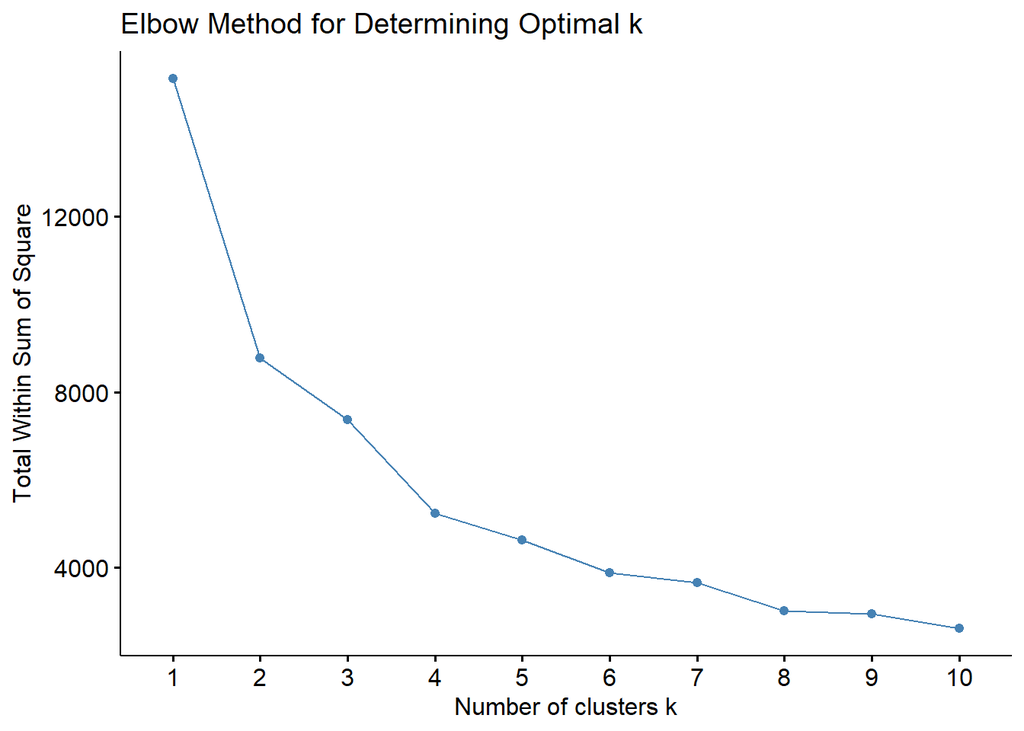

```r
# Elbow method
fviz_nbclust(clustering_data, kmeans, method = "wss") +
  labs(title = "Elbow Method for Determining Optimal k")
```

- Elbow Point at k = 4: The plot exhibits a noticeable “elbow” around **k = 4**. Before **k = 4**, adding more clusters significantly reduces WSS, indicating substantial improvements in cluster compactness. Beyond **k = 4**, the rate of WSS reduction slows down, suggesting diminishing returns in clustering performance.

Based on the Elbow Method, we determined that **4 clusters** is the optimal number for our dataset. This choice balances the complexity of the model with the effectiveness of clustering, ensuring that the clusters are well-defined without introducing unnecessary complexity.

### **3.4.2. Silhouette Analysis**

To further validate the optimal number of clusters, we employed the **Silhouette Analysis**. This method evaluates how similar each data point is to its own cluster compared to other clusters, providing a measure of cluster quality.

We calculated the average silhouette width for different values of **k**:

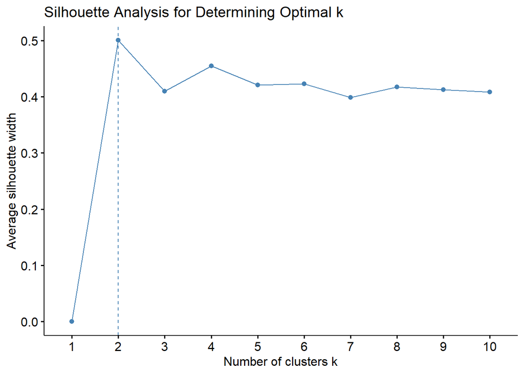

```r
# Silhouette analysis
fviz_nbclust(clustering_data, kmeans, method = "silhouette") +
  labs(title = "Silhouette Analysis for Determining Optimal k")
```

- Peak at k = 2: The highest average silhouette width occurs at **k = 2**, with a value of approximately **0.5**. This indicates that two clusters provide the best separation and cohesion, with data points being well-assigned to their respective clusters.
- Decline After k = 2: After **k = 2**, the average silhouette width slightly decreases and stabilizes. This suggests that adding more clusters beyond two does not significantly enhance the clustering quality, as the improvement in silhouette width is minimal.

### **3.4.3. Gap Statistic**

To further validate the optimal number of clusters (**k**) identified by the Elbow Method and Silhouette Analysis, we utilized the **Gap Statistic**. This method compares the total within-cluster variation to that expected under a reference null distribution, providing a robust criterion for selecting **k**.

We setted k.max = 10 to evaluate up to ten clusters and B = 50 for bootstrap sampling to ensure reliability:

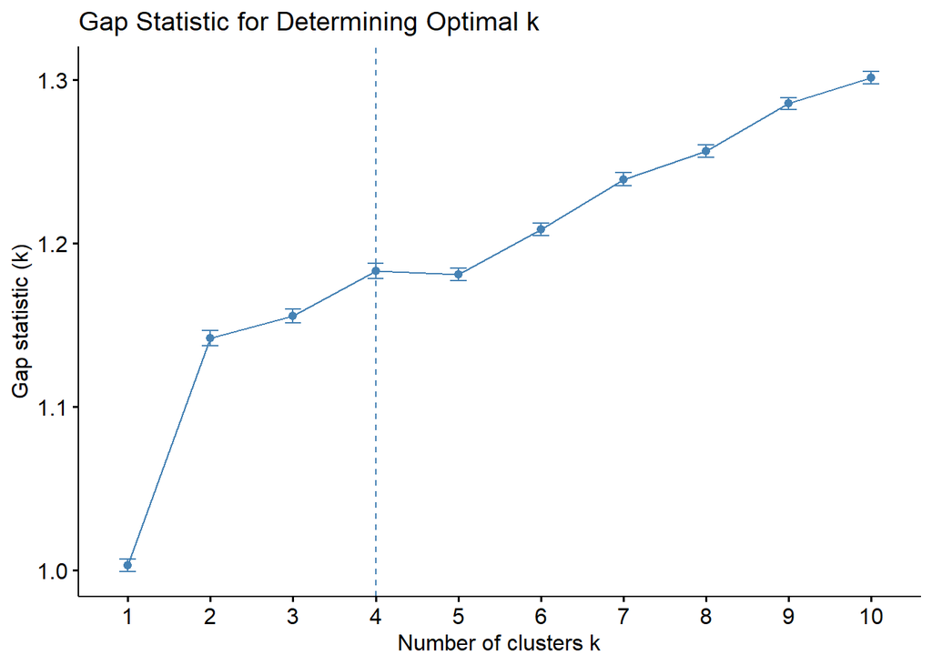

```r
# Gap statistic
set.seed(123)
gap_stat <- clusGap(clustering_data, FUN = kmeans, nstart = 25, K.max = 10, B = 50)
fviz_gap_stat(gap_stat) +
  labs(title = "Gap Statistic for Determining Optimal k")
```

### **3.4.4. Optimal Number of Clusters (k)**

Selecting the appropriate number of clusters (**k**) is pivotal for effective clustering analysis. We utilized three distinct methods to determine the optimal **k** for our dataset: the **Elbow Method**, **Silhouette Analysis**, and the **Gap Statistic**.

Considering the results from all three methods:

- **Elbow Method:** Suggested **k = 4**
- **Silhouette Analysis:** Suggested **k = 2**
- **Gap Statistic:** Suggested **k = 4**

To balance these findings, we determine that **k = 3** is the optimal number of clusters for our dataset. This choice serves as a compromise between the Elbow and Gap Statistic methods, which both indicate **k = 4**, and the Silhouette Analysis, which suggests **k = 2**. Selecting **k = 3** allows us to capture meaningful groupings within the data without overcomplicating the model, ensuring that the clusters are both distinct and representative of underlying patterns.

## **3.5. Applying K-means Clustering**

```r
# Apply K-means clustering with k = 3
set.seed(123)
kmeans_result <- kmeans(clustering_data, centers = 3, nstart = 25)

# View the cluster assignments
head(kmeans_result$cluster)
```

```
## [1] 3 3 3 3 3 3
```

```r
# View the cluster centers
print(kmeans_result$centers)
```

```
##   GDP_per_Capita Diet.low.in.fruits Alochol.use Diet.high.in.sodium
## 1     -0.3423741          1.2536737   1.1255485           1.2806543
## 2      2.8462434         -0.5298232  -0.3830257          -0.5337964
## 3     -0.1723528         -0.4482689  -0.4125651          -0.4587268
```

```r
# View the size of each cluster
print(kmeans_result$size)
```

```
## [1] 1010  273 2502
```

```r
# Total within-cluster sum of squares
print(kmeans_result$tot.withinss)
```

```
## [1] 6558.665
```

**Interpretation of Results:**

- **Cluster 1 (1010 Countries):**
  - **GDP_per_Capita:** Below average
  - **Diet.low.in.fruits, Alochol.use, Diet.high.in.sodium:** Significantly above average This cluster represents countries with lower economic status and poorer dietary habits. High levels of low fruit consumption, alcohol use, and sodium intake indicate challenges in nutritional and health-related behaviors.
- **Cluster 2 (273 Countries):**
  - **GDP_per_Capita:** Significantly above average
  - **Diet.low.in.fruits, Alochol.use, Diet.high.in.sodium:** Below average Countries in this cluster exhibit high economic status coupled with healthier dietary profiles. Lower instances of low fruit consumption, alcohol use, and sodium intake suggest better nutritional and health practices.
- **Cluster 3 (2502 Countries):**
  - **GDP_per_Capita:** Slightly below average
  - **Diet.low.in.fruits, Alochol.use, Diet.high.in.sodium:** Below average This cluster includes countries with slightly below-average economic status and relatively healthier dietary habits. Similar to Cluster 2, but with lower economic indicators, these countries maintain better nutritional behaviors despite modest economic standings.

The K-means clustering algorithm effectively grouped the countries into three distinct clusters based on their economic and dietary profiles:

1. **Cluster 1:** Low GDP per capita and poor dietary habits.
2. **Cluster 2:** High GDP per capita and healthy dietary habits.
3. **Cluster 3:** Slightly below-average GDP per capita and healthy dietary habits.

These clusters reveal meaningful patterns, highlighting the relationship between economic status and dietary behaviors. **Cluster 2** stands out with its combination of high economic indicators and healthy lifestyles, while **Cluster 1** highlights the challenges faced by lower-income countries in maintaining good dietary practices. **Cluster 3** bridges these groups, showcasing that even with modest economic standings, countries can achieve healthier dietary outcomes.

## **3.6. Visualizing the Clustering Results**

To gain a clearer understanding of the clustering outcomes, we visualized the clusters using **Principal Component Analysis (PCA)**. PCA reduces the dimensionality of the data, transforming the original features into principal components that capture the most variance. By projecting the data onto the first two principal components, we can effectively visualize the clustering results in a two-dimensional space.

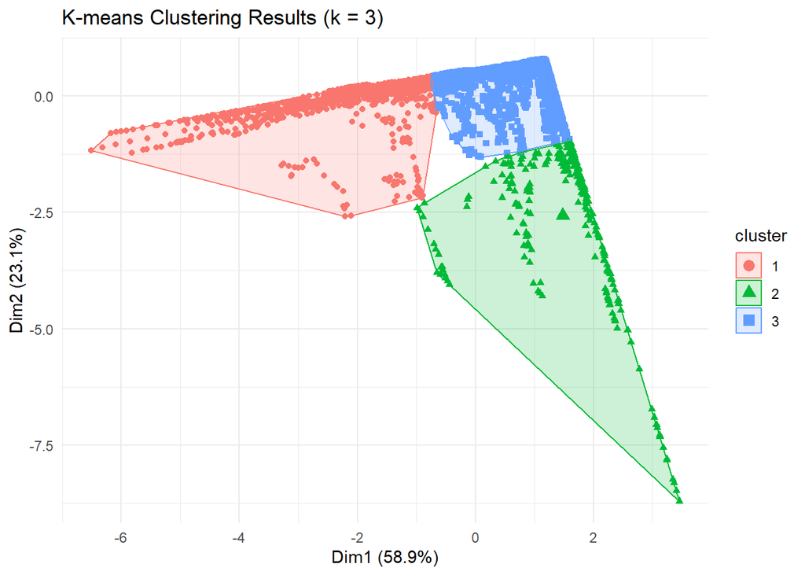

```r
# Visualize clusters using PCA
fviz_cluster(kmeans_result, data = clustering_data,
             ellipse.type = "convex",
             geom = "point",
             stand = FALSE,
             show.clust.cent = TRUE) +
  labs(title = "K-means Clustering Results (k = 3)") +
  theme_minimal()
```

**Interpretation of Results:**

- **Cluster 1:** Comprises countries with lower GDP per capita and poorer dietary habits, indicated by higher values in **Diet.low.in.fruits**, **Alochol.use**, and **Diet.high.in.sodium**.
- **Cluster 2:** Represents countries with significantly higher GDP per capita and healthier dietary profiles, characterized by lower values in the same dietary features.
- **Cluster 3:** Includes countries with moderate GDP per capita and relatively healthier dietary habits compared to Cluster 1, but not as pronounced as those in Cluster 2.

The PCA-based visualization confirms that **k = 3** effectively captures the underlying patterns in the data, distinguishing a clearly separate group of economically prosperous and health-conscious countries (**Cluster 2**), while grouping countries with similar economic and dietary profiles into **Clusters 1 and 3**. This visualization validates our clustering choice, providing clear insights into the economic and dietary distinctions among the countries analyzed.

## **3.7. Discussing the Impact of Distance Measure**

In our clustering analysis, we utilized **Euclidean distance** as the distance metric. This choice plays a pivotal role in how the clustering algorithm groups the countries based on their feature similarities.

By employing Euclidean distance on our **standardized** dataset, each feature contributes equally to the distance calculations. This means that countries are grouped together based on their overall similarity across all selected features—**GDP_per_Capita**, **Diet.low.in.fruits**, **Alochol.use**, and **Diet.high.in.sodium**. The standardization ensures that no single feature dominates the clustering process due to its scale, allowing the algorithm to consider the combined effect of all features uniformly.

As a result, clusters formed using Euclidean distance reflect comprehensive profiles of the countries, capturing both economic and dietary characteristics cohesively. This leads to well-defined and meaningful groupings, as observed in our visualization where distinct clusters emerged based on the integrated feature values.

Choosing Euclidean distance, in conjunction with data standardization, ensured that our clustering algorithm effectively identified groups of countries with similar economic and dietary profiles. This metric facilitated the formation of balanced and interpretable clusters, enhancing our ability to uncover underlying patterns within the data.

## **3.8. Summary of Clustering Results**

**Cluster Characteristics:**

- **Cluster 1 (1010 Countries):**
  - **Economic Status:** Below-average GDP per capita.
  - **Dietary Habits:** Higher levels of low fruit consumption, alcohol use, and high sodium intake.
  - **Implications:** Represents countries with lower economic standing and poorer dietary practices, potentially correlating with higher mortality rates.
- **Cluster 2 (273 Countries):**
  - **Economic Status:** Significantly higher GDP per capita.
  - **Dietary Habits:** Lower levels of low fruit consumption, alcohol use, and high sodium intake.
  - **Implications:** Encompasses economically prosperous countries with healthier dietary profiles, likely associated with lower mortality rates.
- **Cluster 3 (2502 Countries):**
  - **Economic Status:** Slightly below-average GDP per capita.
  - **Dietary Habits:** Relatively low levels of low fruit consumption, alcohol use, and high sodium intake.
  - **Implications:** Includes countries with moderate economic status and healthier dietary behaviors compared to Cluster 1, indicating better health outcomes despite modest economic indicators.

**Impact of Distance Measure:**

Utilizing **Euclidean distance** on standardized data ensured that each feature contributed equally to the clustering process. This approach facilitated the formation of cohesive clusters based on overall similarity across economic and dietary factors, resulting in meaningful and interpretable groupings.

**Effectiveness of Clustering:**

The PCA-based visualization confirmed the distinctiveness of the three clusters:

- **Cluster 2** was clearly separated, highlighting its unique combination of high economic status and healthy dietary habits.
- **Clusters 1 and 3** exhibited some overlap, reflecting similarities in their feature profiles but maintaining distinct groupings based on economic and dietary differences.

Overall, the clustering analysis successfully identified three distinct groups of countries, providing valuable insights into how economic and dietary factors interplay to influence mortality rates. These findings underscore the importance of both economic prosperity and healthy dietary practices in shaping health outcomes across different regions.

# **Section 4: Interactive Exploration with Shiny App**

To enhance the exploratory data analysis (EDA) and provide an interactive platform for users to delve deeper into the results, we developed a **Shiny App**. This application facilitates dynamic exploration of single variable performances, comparison of classification models, and visualization of clustering outcomes.

## **4.1. Shiny App Overview**

The Shiny App is designed with a user-friendly interface that organizes various analytical components into intuitive sections. It enables users to interactively explore:

- **Exploratory Data Analysis:** Access to single-variable and multiple-variable visualizations.
- **Single Variable Model Performance:** Assess the impact and performance metrics of individual features.
- **Classification Model Performance:** Compare the performance of the Decision Tree and Logistic Regression classifiers.
- **Clustering Results:** Visualize and interpret the clustering outcomes based on selected features.

## **4.2. Demonstration Video**

A short **2-3 minute video** demonstrates the functionalities of the Shiny App, highlighting its interactive features and how it supports exploratory data analysis. [**Watch the Demonstration Video Here**](https://youtu.be/9IIQfb88t9U)

The video includes a walkthrough of the app’s interface, showcasing how to navigate between tabs, interact with plots, and interpret the results effectively.

# **Conclusion**

This project offered a thorough analysis of the factors influencing mortality rates across various countries by combining health-related metrics from the WHO dataset with economic indicators from the World Bank. One of the key findings is the significant economic impact on health outcomes; higher GDP per Capita is linked to lower mortality rates, underscoring the importance of economic prosperity in enhancing public health. Additionally, elevated levels of outdoor air pollution, high systolic blood pressure, smoking rates, and high sodium intake were found to correlate with increased mortality rates, highlighting the critical role of environmental and lifestyle factors in shaping health outcomes.

In our predictive modeling efforts, we utilized Decision Tree and Logistic Regression classifiers to forecast mortality rates. The Decision Tree model outperformed Logistic Regression, effectively distinguishing between high and low mortality classes with greater accuracy and reliability. Furthermore, through K-means clustering, countries were categorized into distinct groups based on their economic and dietary profiles, revealing patterns that align closely with observed health outcomes.

Based on these insights, several recommendations emerge. Public health policies should focus on implementing targeted interventions to reduce air pollution, promote healthy diets, and curb smoking to lower mortality rates. Strengthening economic growth strategies is also essential, as it lays the foundation for enhancing healthcare infrastructure and access. Additionally, enforcing stricter environmental regulations can mitigate the adverse effects of pollution on public health.

Overall, the findings from this analysis emphasize the interconnectedness of economic status, environmental conditions, and lifestyle choices in determining mortality rates. By leveraging these insights, policymakers and health professionals can develop effective strategies and policies aimed at reducing mortality and improving global health standards.